# HW6

賴冠維

2020/12/22

```r
library(magrittr)
```

## (8)

本題使用資料為${ISLR}$裡的$Carseats$  
有 400 observations 及 11 variables，變數解釋如下：  
* Sales  
Unit sales (in thousands) at each location  
* CompPrice  
Price charged by competitor at each location  
* Income  
Community income level (in thousands of dollars)  
* Advertising  
Local advertising budget for company at each location (in thousands of dollars)  
* Population  
Population size in region (in thousands)  
* Price  
Price company charges for car seats at each site  
* ShelveLoc  
A factor with levels Bad, Good and Medium indicating the quality of the shelving location for the car seats at each site  
* Age  
Average age of the local population  
* Education  
Education level at each location  
* Urban  
A factor with levels No and Yes to indicate whether the store is in an urban or rural location  
* US  
A factor with levels No and Yes to indicate whether the store is in the US or not

### (a)

將$Carseats$以$[80,20]$比例分割成$Train,Test$

```r
# 8
## (a)
library(ISLR)
library(tree)
data("Carseats")
Carseats$Sales_1 = as.factor(ifelse(Carseats$Sales <= 8, "Low", "High"))
set.seed(1234567)
index = sample(1:400,size = 320,replace = F)
train = Carseats[index,]
test = Carseats[-index,]
cat("Train:",dim(train),"Test:",dim(test))
```

```
## Train: 320 12 Test: 80 12
```

### (b)

建立$Regression\ Tree$預測$Sales$，下圖為預測結果，  
節點左邊為$Yes$，右邊為$No$  
模型裡僅用到$"ShelveLoc" "Price" "Age" "CompPrice" "Advertising"$  
一共有15個$terminal\ nodes$

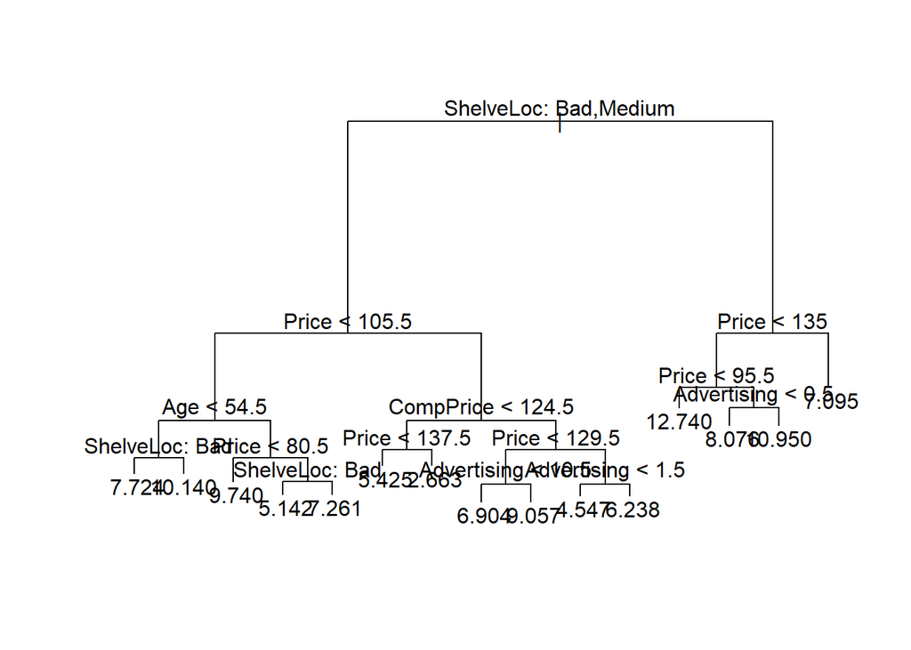

```r
## (b)
model = tree(Sales~.,data = train[,-12])
plot(model)
text(model,pretty = 0)
```

```r
summary(model)
```

```
##
## Regression tree:
## tree(formula = Sales ~ ., data = train[, -12])
## Variables actually used in tree construction:
## [1] "ShelveLoc"   "Price"       "Age"         "CompPrice"   "Advertising"
## Number of terminal nodes:  15
## Residual mean deviance:  2.641 = 805.4 / 305
## Distribution of residuals:
##     Min.  1st Qu.   Median     Mean  3rd Qu.     Max.
## -4.54700 -1.08400 -0.09094  0.00000  1.17500  3.88500
```

```r
fit= predict(model,test[,-12])
paste0("Test Error MSE: ",sum((test$Sales - fit)^2)/nrow(test)) #rmse
```

```
## [1] "Test Error MSE: 4.72828433855961"
```

```r
fit = ifelse(fit<=8,"Low","High")
table(predicted = fit, actual = test$Sales_1)
```

```
##          actual
## predicted High Low
##      High   15   5
##      Low    18  42
```

```r
accuracy = function(actual, predicted) {
  mean(actual == predicted)
}
cat("Test Error Rate:",1-accuracy(predicted = fit, actual = test$Sales_1))
```

```
## Test Error Rate: 0.2875
```

### (c)

使用$Cross\ Validation$，選出具有最佳的預測力的樹複雜度  
以$K=10$，$10 \ Fold$進行$Cross\ Validation$，選到15個$Terminal\ Nodes$  
由圖亦可看到誤差隨著$Size$增加而遞減至收斂  
與上述模型相同，因此得到相同的$Test\ Error\ Rate$

```r
## (c)
set.seed(1234)
tree_cv = cv.tree(model, FUN = prune.tree,K = 10)
min_idx = which.min(tree_cv$dev)
paste("Best Size :",tree_cv$size[min_idx])
```

```
## [1] "Best Size : 15"
```

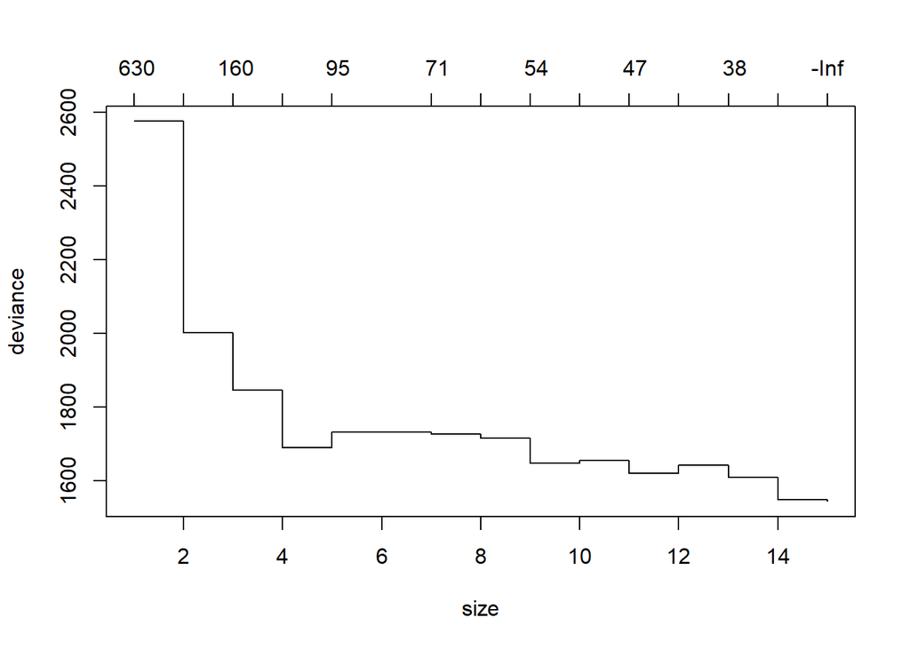

```r
# default plot
plot(tree_cv)
```

```r
tree_prune = prune.tree(model,best = tree_cv$size[min_idx])
fit= predict(tree_prune,test)
paste0("Test Error MSE: ",sum((test$Sales - fit)^2)/nrow(test)) #rmse
```

```
## [1] "Test Error MSE: 4.72828433855961"
```

```r
fit = ifelse(fit<=8,"Low","High")
table(predicted = fit, actual = test$Sales_1)
```

```
##          actual
## predicted High Low
##      High   15   5
##      Low    18  42
```

```r
cat("Test Error Rate:",1-accuracy(predicted = fit, actual = test$Sales_1))
```

```
## Test Error Rate: 0.2875
```

### (d)

接下來以$Bagging$方式預測，$Bagging$與$Random Forest $僅差在建立子集$(Subset)$時， 是否也對$Columns$進行抽樣，因此以$random Forest$套件進行即可 以相同流程對$Test$估計，$RMSE$明顯較低 並且從$Confusion Table$及$Test Error Rate$亦可看出，預測表現較佳。 由$Variance Importance Plot$可看出個別變數對模型的貢獻度， 發現$Price、SheleveLoc$這兩個變數解釋力為最佳。

```r
##(d)
library(randomForest)
bag = randomForest(Sales ~., data = train[,-12], mtry= 10,
                  importance = TRUE, ntrees = 500)
fit= predict(bag,test[,-12])
paste0("Test Error MSE: ",sum((test$Sales - fit)^2)/nrow(test)) #rmse
```

```
## [1] "Test Error MSE: 2.4401977490189"
```

```r
fit = ifelse(fit<=8,"Low","High")
table(predicted = fit, actual = test$Sales_1)
```

```
##          actual
## predicted High Low
##      High   22   4
##      Low    11  43
```

```r
cat("Test Error Rate:",1-accuracy(predicted = fit, actual = test$Sales_1))
```

```
## Test Error Rate: 0.1875
```

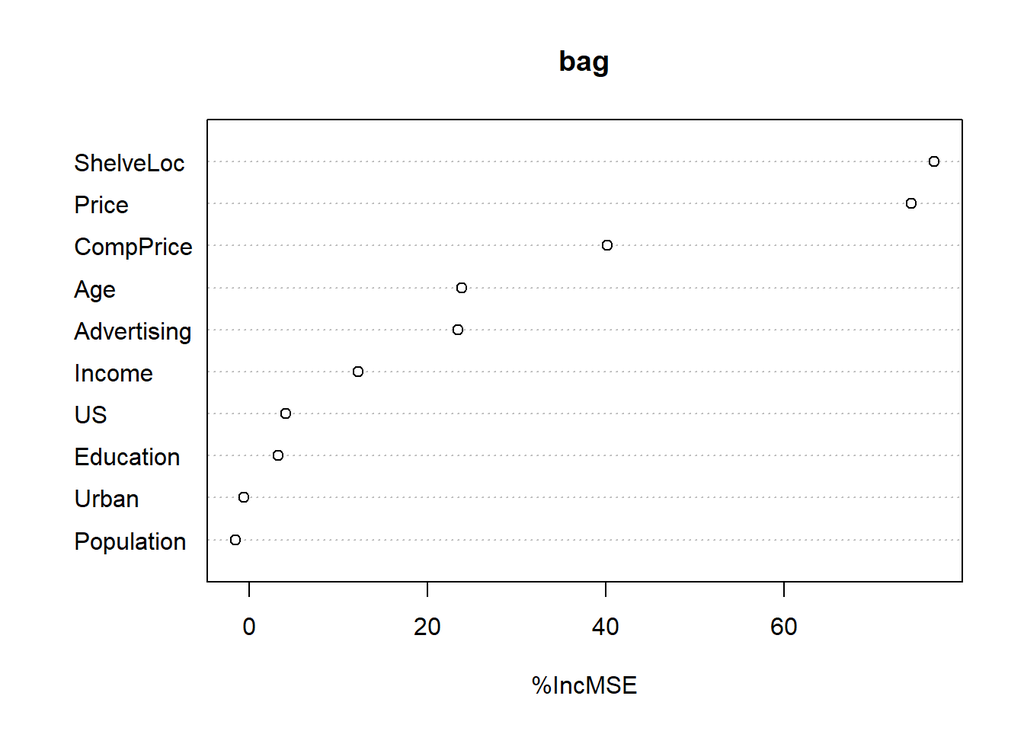

```r
varImpPlot(bag, type = 1)
```

### (e)

接下來以$Random\ Forest$進行配適，選取$Column\ Split$以$p/3$為標準$=4$  
以相同步驟估計，最後可看到$Random\ Forest$表現比$Bagging$更佳。

```r
## (e)
library(randomForest)
rf = randomForest(Sales ~., data = train[,-12],mtry=4,
                          importance = TRUE, ntrees = 500)
fit= predict(rf,test[,-12])
paste0("Test Error MSE: ",sum((test$Sales - fit)^2)/nrow(test)) #rmse
```

```
## [1] "Test Error MSE: 2.32105249762642"
```

```r
fit = ifelse(fit<=8,"Low","High")
table(predicted = fit, actual = test$Sales_1)
```

```
##          actual
## predicted High Low
##      High   23   4
##      Low    10  43
```

```r
cat("Test Error Rate:",1-accuracy(predicted = fit, actual = test$Sales_1))
```

```
## Test Error Rate: 0.175
```

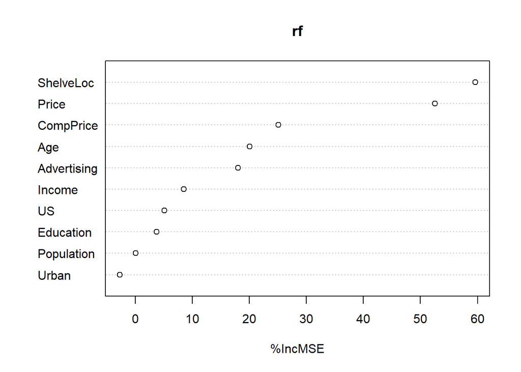

```r
varImpPlot(rf, type = 1)
```

## (9)

本題使用資料為${ISLR}$裡的$OJ$  
有 1070 observations 及 18 variables，變數解釋如下：  
* Purchase  
A factor with levels CH and MM indicating whether the customer purchased Citrus Hill or Minute Maid Orange Juice  
* WeekofPurchase  
Week of purchase  
* StoreID  
Store ID  
* PriceCH  
Price charged for CH  
* PriceMM  
Price charged for MM  
* DiscCH  
Discount offered for CH  
* DiscMM  
Discount offered for MM  
* SpecialCH  
Indicator of special on CH  
* SpecialMM  
Indicator of special on MM  
* LoyalCH  
Customer brand loyalty for CH  
* SalePriceMM  
Sale price for MM  
* SalePriceCH  
Sale price for CH  
* PriceDiff  
Sale price of MM less sale price of CH  
* Store7  
A factor with levels No and Yes indicating whether the sale is at Store 7  
* PctDiscMM  
Percentage discount for MM  
* PctDiscCH  
Percentage discount for CH  
* ListPriceDiff  
List price of MM less list price of CH  
* STORE  
Which of 5 possible stores the sale occured at

## (9)

### (a)

```r
# (9)
## (a)
data(OJ)
index = sample(1:1070,800,replace = F)
train = OJ[index,]
test = OJ[-index,]

cat("Train:",dim(train),"Test:",dim(test))
```

```
## Train: 800 18 Test: 270 18
```

### (b)

```r
## (b)
tree = tree(Purchase~.,data = train)
summary(tree)
```

```
##
## Classification tree:
## tree(formula = Purchase ~ ., data = train)
## Variables actually used in tree construction:
## [1] "LoyalCH"   "PriceDiff"
## Number of terminal nodes:  8
## Residual mean deviance:  0.7916 = 626.9 / 792
## Misclassification error rate: 0.1762 = 141 / 800
```

以$Terminal\ Nodes\ (10)$為例解釋，當$LoyalCH < 0.48285，LoyalCH > 0.0356415$，且$PriceDiff < 0.085$時，  
在$Train Set$裡共有97筆資料落在此$Nodes$，將此$Nodes$預測為$MM$，並且正確率為0.82474

```r
#(c)
tree
```

```
## node), split, n, deviance, yval, (yprob)
##       * denotes terminal node
##
##  1) root 800 1064.000 CH ( 0.61750 0.38250 )
##    2) LoyalCH < 0.48285 292  330.600 MM ( 0.25342 0.74658 )
##      4) LoyalCH < 0.0356415 54    9.959 MM ( 0.01852 0.98148 ) *
##      5) LoyalCH > 0.0356415 238  293.400 MM ( 0.30672 0.69328 )
##       10) PriceDiff < 0.085 97   90.040 MM ( 0.17526 0.82474 ) *
##       11) PriceDiff > 0.085 141  189.500 MM ( 0.39716 0.60284 )
##         22) LoyalCH < 0.104032 18    7.724 MM ( 0.05556 0.94444 ) *
##         23) LoyalCH > 0.104032 123  169.100 MM ( 0.44715 0.55285 ) *
##    3) LoyalCH > 0.48285 508  468.300 CH ( 0.82677 0.17323 )
##      6) LoyalCH < 0.764572 245  300.200 CH ( 0.69796 0.30204 )
##       12) PriceDiff < -0.165 33   31.290 MM ( 0.18182 0.81818 ) *
##       13) PriceDiff > -0.165 212  224.300 CH ( 0.77830 0.22170 )
##         26) PriceDiff < 0.265 116  145.300 CH ( 0.68103 0.31897 ) *
##         27) PriceDiff > 0.265 96   64.160 CH ( 0.89583 0.10417 ) *
##      7) LoyalCH > 0.764572 263  109.400 CH ( 0.94677 0.05323 ) *
```

### (d)

由圖亦可看到上述結果

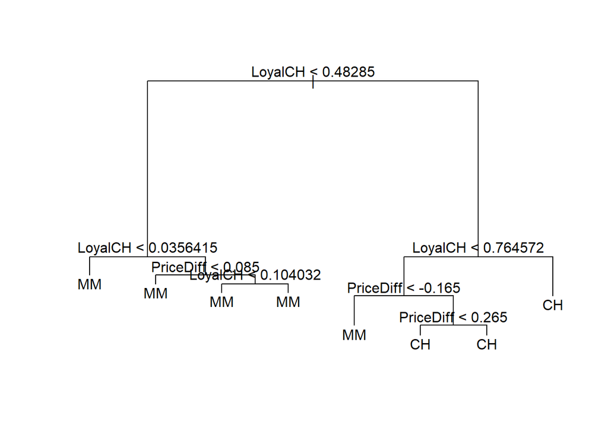

```r
#(d)
plot(tree)
text(tree)
```

### (e)

由$Confusion Table$及$Test\ Error\ Rate$看出對Test的估計結果，  
$Test\ Error\ Rate$為0.1518519

```r
#(e)
fit=predict(tree,test,type = "class")
table(predicted = fit, actual = test$Purchase)
```

```
##          actual
## predicted  CH  MM
##        CH 133  15
##        MM  26  96
```

```r
cat("Test Error Rate:",1-accuracy(predicted = fit, actual = test$Purchase))
```

```
## Test Error Rate: 0.1518519
```

### (f)

以$cv.tree$優化模型

```r
#(f)
cv_tree = cv.tree(tree, FUN = prune.misclass)
summary(cv_tree)
```

```
##        Length Class  Mode
## size   4      -none- numeric
## dev    4      -none- numeric
## k      4      -none- numeric
## method 1      -none- character
```

### (g)

可以看到優化結果顯示，$Nodes$為8時，有最佳的表現。

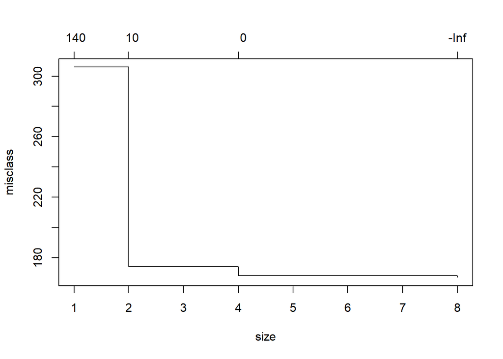

```r
#(g)
plot(cv_tree)
```

### (h)

由上述結果，以$Terminal\ Nodes$為8，進行配飾

```r
#(h)
min_idx = which.min(cv_tree$dev)
cat("Best Size: ",cv_tree$size[min_idx])
```

```
## Best Size:  8
```

### (i)

以上述優化結果與先前相同，因此並無改善。

```r
#(i)
tree_prune = prune.tree(tree,best = cv_tree$size[min_idx])
fit= predict(tree_prune,test,type="class")
table(predicted = fit, actual = test$Purchase)
```

```
##          actual
## predicted  CH  MM
##        CH 133  15
##        MM  26  96
```

```r
cat("Test Error Rate:",1-accuracy(predicted = fit, actual = test$Purchase))
```

```
## Test Error Rate: 0.1518519
```

### (j)

優化前後模型並無差別，因此$Train\ Error\ Rate$並無改善。

```r
#(j)
fit= predict(tree,train,type="class")
fit_1= predict(tree_prune,train,type="class")

paste0("Train_Unpruned Error Rate: ",1- accuracy(predicted = fit, actual = train$Purchase))
```

```
## [1] "Train_Unpruned Error Rate: 0.17625"
```

```r
paste0("Train_Pruned Error Rate: ",1- accuracy(predicted = fit_1, actual = train$Purchase))
```

```
## [1] "Train_Pruned Error Rate: 0.17625"
```

### (k)

優化前後模型並無差別，因此$Test\ Error\ Rate$並無改善。

```r
#(k)
fit= predict(tree,test,type="class")
fit_1= predict(tree_prune,test,type="class")

paste0("Test_Unpruned Error Rate: ",1- accuracy(predicted = fit, actual = test$Purchase))
```

```
## [1] "Test_Unpruned Error Rate: 0.151851851851852"
```

```r
paste0("Test_Pruned Error Rate: ",1- accuracy(predicted = fit_1, actual = test$Purchase))
```

```
## [1] "Test_Pruned Error Rate: 0.151851851851852"
```

## (10)

本題使用資料為${ISLR}$裡的$Hitters$  
有 322 observations 及 20 variables，變數解釋如下：  
* AtBat  
Number of times at bat in 1986  
* Hits  
Number of hits in 1986  
* HmRun  
Number of home runs in 1986  
* Runs  
Number of runs in 1986  
* RBI  
Number of runs batted in in 1986  
* Walks  
Number of walks in 1986  
* Years  
Number of years in the major leagues  
* CAtBat  
Number of times at bat during his career  
* CHits  
Number of hits during his career  
* CHmRun  
Number of home runs during his career  
* CRuns  
Number of runs during his career  
* CRBI  
Number of runs batted in during his career  
* CWalks  
Number of walks during his career  
* League  
A factor with levels A and N indicating player’s league at the end of 1986  
* Division  
A factor with levels E and W indicating player’s division at the end of 1986  
* PutOuts  
Number of put outs in 1986  
* Assists  
Number of assists in 1986  
* Errors  
Number of errors in 1986  
* Salary  
1987 annual salary on opening day in thousands of dollars  
* NewLeague  
A factor with levels A and N indicating player’s league at the beginning of 1987

### (a)

首先將由遺漏值的資料刪去後，再將目標解釋變數$Salary$取對數

```r
#(10)
## (a)
data("Hitters")
Hitters = na.omit(Hitters)
Hitters$Salary = log(Hitters$Salary)
```

### (b)

以前200筆為$Train$，剩下為$Test$

```r
## (b)
train = Hitters[1:200,]
test = Hitters[201:263,]
cat("Train:",dim(train),"Test:",dim(test))
```

```
## Train: 200 20 Test: 63 20
```

### (c)

取$0.001到0.01$之間10等分為$shrinkage$，可以看到$Train Error$隨$shrinkage$增加而降低。

```r
## (c)
library(gbm)
```

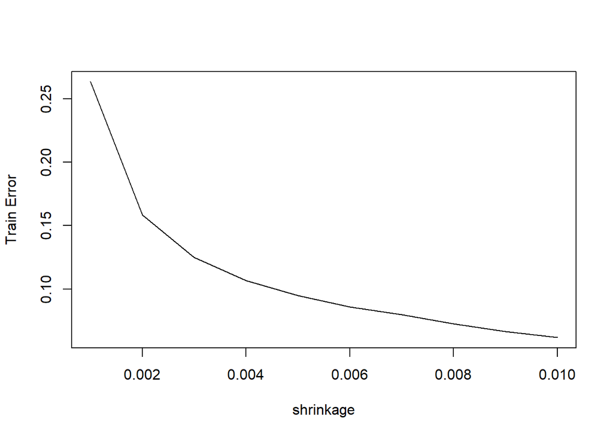

```r
s = seq(0.001,0.01,by = 0.001)
t = sapply(1:10, function(a){
  boost = gbm(Salary ~ ., data = train, distribution = "gaussian",
                    n.trees = 1000, interaction.depth = 4, shrinkage = s[a])
  c(boost$shrinkage,tail(boost$train.error,1))
})
t = t(t) %>% as.data.frame()
names(t)= c("shrinkage","train_error")
plot(x=t$shrinkage,y=t$train_error,type="l",xlab = "shrinkage",ylab = "Train Error")
```

### (d)

以相同$Shrinkage\ Set$進行$Train$的配適，但所得到的$Test Error$並不像$Train Error$穩健遞減，偶有反升的趨勢。

```r
## (d)
s = seq(0.001,0.01,by = 0.001)
t = sapply(1:10, function(a){
  boost = gbm(Salary ~ ., data = train, distribution = "gaussian",
              n.trees = 1000, interaction.depth = 4, shrinkage = s[a])
  fit = predict(boost,test)
  mse = mean((fit-test$Salary)^2)
  c(boost$shrinkage,mse)
})
```

[output not shown]

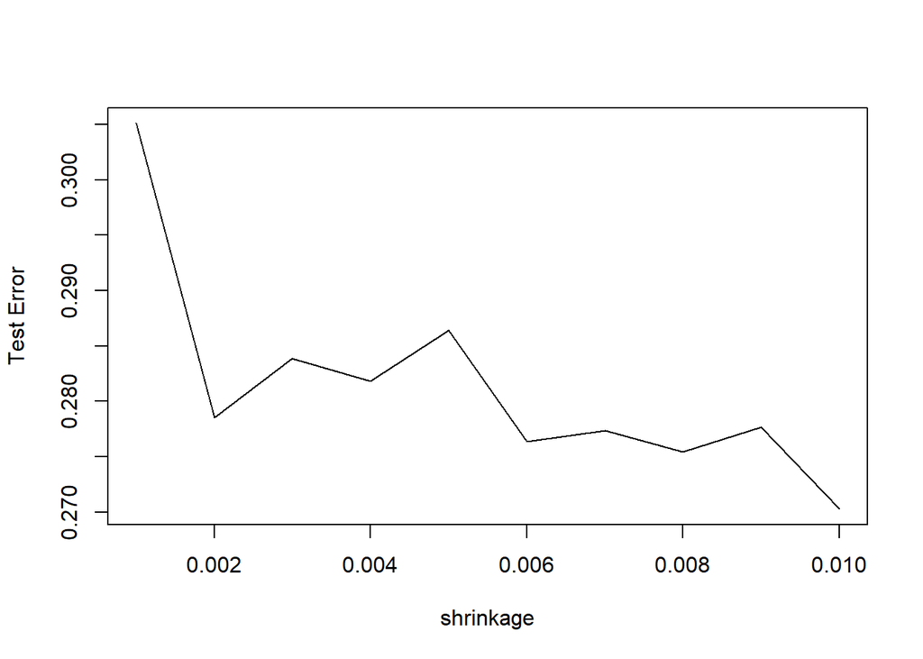

```r
t = t(t) %>% as.data.frame()
names(t)= c("shrinkage","test_error")
plot(x=t$shrinkage,y=t$test_error,type="l",xlab = "shrinkage",ylab = "Test Error")
```

### (e)

```r
#(e)
library(glmnet)
lm = lm(Salary ~ ., data = train)
fit = predict(lm,test)
paste0("Test Error MSE of LM: ",sum((test$Salary - fit)^2)/nrow(test)) #rmse
```

```
## [1] "Test Error MSE of LM: 0.491795937545494"
```

```r
train_1 = model.matrix(Salary ~ ., data = train)
test_1 = model.matrix(Salary ~ ., data = test)
y = train$Salary
lasso = glmnet(train_1, y, alpha = 0)
fit = predict(lasso, s = 0.01, newx = test_1)
paste0("Test Error MSE of Lasso: ",sum((test$Salary - fit)^2)/nrow(test)) #rmse
```

```
## [1] "Test Error MSE of Lasso: 0.457028250141243"
```

```r
boost = gbm(Salary ~ ., data = train, distribution = "gaussian",
              n.trees = 1000, interaction.depth = 4, shrinkage = s[10])
fit = predict(boost,test)
```

```
## Using 1000 trees...
```

```r
paste0("Test Error MSE of Boosting: ",sum((test$Salary - fit)^2)/nrow(test)) #rmse
```

```
## [1] "Test Error MSE of Boosting: 0.287606612725594"
```

### (f)

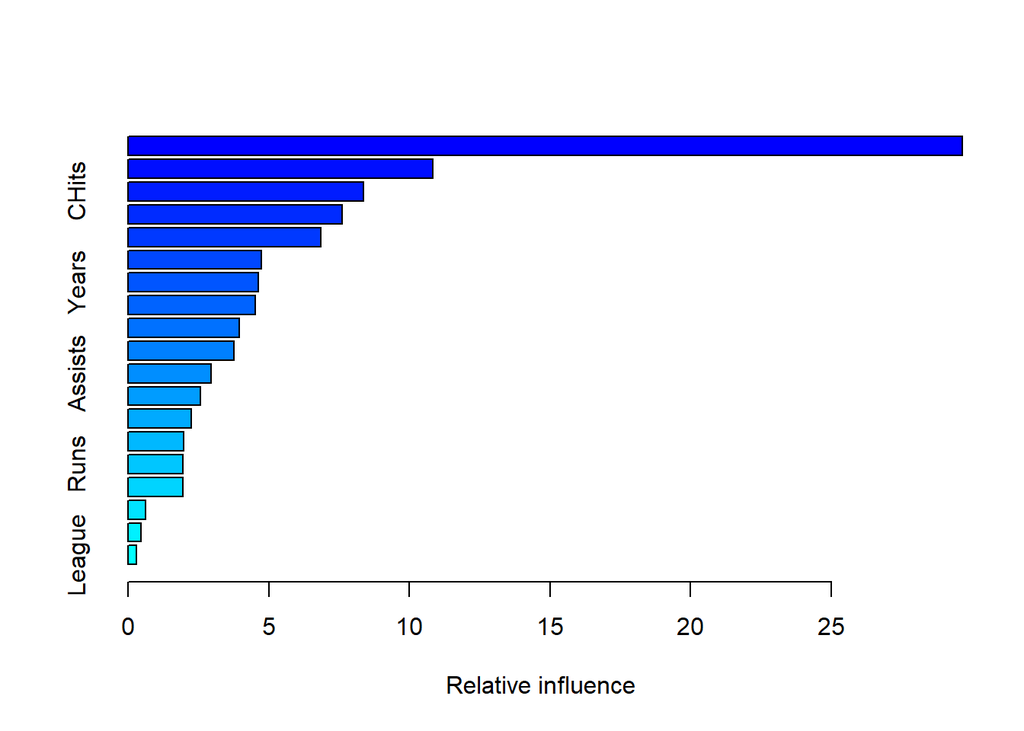

```
##                 var    rel.inf
## CAtBat       CAtBat 29.6511477
## CWalks       CWalks 10.8355583
## CHits         CHits  8.3629778
## CRuns         CRuns  7.6238787
## CRBI           CRBI  6.8453865
## PutOuts     PutOuts  4.7338062
## Years         Years  4.6380926
## Walks         Walks  4.5147326
## AtBat         AtBat  3.9595985
## CHmRun       CHmRun  3.7707869
## Assists     Assists  2.9486224
## RBI             RBI  2.5755878
## Hits           Hits  2.2579686
## HmRun         HmRun  1.9932002
## Runs           Runs  1.9551249
## Errors       Errors  1.9504051
## NewLeague NewLeague  0.6191589
## Division   Division  0.4644946
## League       League  0.2994717
```

```r
#(f)
summary(boost)
```

### (g)

此處使用$Bagging$，發現$Test MSE$ 表現比$Boosting$更佳。

```r
#(g)
bag <- randomForest(Salary ~ ., data = train, mtry = 19, ntree = 500)
fit <- predict(bag, newdata = test)
paste0("Test Error MSE of Bagging: ",sum((test$Salary - fit)^2)/nrow(test)) #rmse
```

```
## [1] "Test Error MSE of Bagging: 0.234267450868388"
```